# Project 2 — Data Tidying: State Unemployment

Author

Aniss Sahraoui

Published

October 10, 2026

```r
library(tidyverse)
library(knitr)

# Shared styling, used across all three Project 2 reports
accent   <- "#2a78d6"
accent_2 <- "#eb6834"
theme_p2 <- theme_minimal(base_size = 12) +
  theme(panel.grid.minor = element_blank(), plot.title.position = "plot")
```

# Data Source

This dataset comes from the Discussion 5A post **“U.S. Bureau of Labor Statistics Table”** by Zaina Hassan, who describes the problem with it:

> “I consider this dataset untidy because the dates and measurements are spread across multiple columns and levels of column headings rather than each variable having its own individual column. … This wide format makes the table fairly easy for a person to read on the webpage, but it would need to be reorganized before it could be easily analyzed in R.”

and states the analysis:

> “One analysis I could perform after tidying the dataset would be to compare unemployment rates between states and examine how they change over time. I could also identify which states experienced the largest increases or decreases in unemployment during the time period represented in the table.”

**Source:** U.S. Bureau of Labor Statistics, *State and Regional Unemployment*, Table 1: “Employment status of the civilian noninstitutional population 16 years of age and over by region, division, and state, 2023-24 annual averages” (https://www.bls.gov/news.release/srgune.t01.htm).

I checked the transcription by verifying that *employed + unemployed = civilian labor force* in every row, which it does to within one thousand (the table is rounded to thousands).

# Data Structure Before Tidying

```r
raw_jobs <- read_csv(
  "https://raw.githubusercontent.com/AnissSahraoui/DATA607/main/Week6/data/state_unemployment_wide.csv",
  show_col_types = FALSE
)

dim(raw_jobs)
```

```
[1] 66 12
```

```r
names(raw_jobs)
```

```
 [1] "Region, division, and state" "Population | 2023"
 [3] "Population | 2024"           "Civilian labor force | 2023"
 [5] "Civilian labor force | 2024" "Employed | 2023"
 [7] "Employed | 2024"             "Unemployed | 2023"
 [9] "Unemployed | 2024"           "Unemployment rate | 2023"
[11] "Unemployment rate | 2024"    "Error range of rate, 2024"
```

```r
raw_jobs |> slice_head(n = 5) |> select(1:6)
```

```
# A tibble: 5 × 6
  `Region, division, and state` `Population | 2023` `Population | 2024`
  <chr>                                       <dbl>               <dbl>
1 United States                              266942              268571
2 Northeast                                   46640               47056
3 New England                                 12575               12696
4 Connecticut                                  2969                2999
5 Maine                                        1165                1173
# ℹ 3 more variables: `Civilian labor force | 2023` <dbl>,
#   `Civilian labor force | 2024` <dbl>, `Employed | 2023` <dbl>
```

```r
tibble(column = names(raw_jobs), type = map_chr(raw_jobs, ~ class(.x)[1])) |>
  slice_head(n = 6) |>
  kable()
```

| column | type |
| --- | --- |
| Region, division, and state | character |
| Population \| 2023 | numeric |
| Population \| 2024 | numeric |
| Civilian labor force \| 2023 | numeric |
| Civilian labor force \| 2024 | numeric |
| Employed \| 2023 | numeric |

# Transformation Steps

```r
# The region and division names printed in the table's stub column. Listing them
# explicitly is the only reliable way to tell a region row from a state row.
regions <- c(
  "United States",
  "Northeast", "New England", "Middle Atlantic",
  "Midwest", "East North Central", "West North Central",
  "South", "South Atlantic", "East South Central", "West South Central",
  "West", "Mountain", "Pacific"
)

jobs <- raw_jobs |>
  # 1. Rename to snake_case. The first column's name is a sentence in the source.
  rename(
    area        = `Region, division, and state`,
    error_range = `Error range of rate, 2024`
  ) |>
  # 2. Reshape wide to long, splitting each "Measure | Year" heading into two
  #    columns. This is what turns the two-level header into real variables.
  pivot_longer(
    cols      = contains("|"),
    names_to  = c("measure", "year"),
    names_sep = " \\| ",
    values_to = "value"
  ) |>
  # 3. Normalize types and labels.
  mutate(
    value   = as.numeric(str_remove_all(value, ",")),   # "266,942" -> 266942
    year    = as.integer(year),
    measure = str_replace_all(str_to_lower(measure), " ", "_"),
    # 4. Add the geography level that was implicit in the row ordering, so the
    #    three levels can be separated instead of being summed together.
    area_type = case_when(
      area %in% regions ~ "region_or_division",
      area == "Puerto Rico" ~ "territory",
      TRUE ~ "state"
    )
  )

glimpse(jobs)
```

```
Rows: 660
Columns: 6
$ area        <chr> "United States", "United States", "United States", "United…
$ error_range <chr> "3.9 - 4.1", "3.9 - 4.1", "3.9 - 4.1", "3.9 - 4.1", "3.9 -…
$ measure     <chr> "population", "population", "civilian_labor_force", "civil…
$ year        <int> 2023, 2024, 2023, 2024, 2023, 2024, 2023, 2024, 2023, 2024…
$ value       <dbl> 266942.0, 268571.0, 167116.0, 168106.0, 161037.0, 161346.0…
$ area_type   <chr> "region_or_division", "region_or_division", "region_or_div…
```

```r
# Record the units, which the source gives only in a note above the table.
units <- tribble(
  ~measure,              ~unit,
  "population",          "thousands of people",
  "civilian_labor_force","thousands of people",
  "employed",            "thousands of people",
  "unemployed",          "thousands of people",
  "unemployment_rate",   "percent of labor force"
)

units |> kable(col.names = c("Measure", "Unit"))
```

| Measure | Unit |
| --- | --- |
| population | thousands of people |
| civilian_labor_force | thousands of people |
| employed | thousands of people |
| unemployed | thousands of people |
| unemployment_rate | percent of labor force |

```r
jobs |>
  summarise(
    rows                   = n(),
    missing_numeric_values = sum(is.na(value))
  ) |>
  kable()
```

| rows | missing_numeric_values |
| --- | --- |
| 660 | 0 |

```r
# The error range column is text, and one row carries a footnote marker instead of a range.
jobs |>
  distinct(area, error_range) |>
  filter(str_detect(error_range, "\\(")) |>
  kable()
```

| area | error_range |
| --- | --- |
| Puerto Rico | (2) |

Every numeric value is present. The one inconsistency is in `error_range`, where Puerto Rico shows `(2)`, a footnote meaning “data not available”, rather than a range like `3.9 - 4.1`. I convert that marker to a proper `NA` rather than leaving the string in place, because `(2)` is not a value and would otherwise be silently treated as one:

```r
jobs <- jobs |>
  mutate(error_range = if_else(str_detect(error_range, "\\("), NA_character_, error_range))

sum(is.na(jobs$error_range)) / n_distinct(jobs$measure) / n_distinct(jobs$year)
```

```
[1] 1
```

**A check on the reshaping.** The unemployment rate should equal unemployed divided by labor force. Recomputing it from two other columns confirms the long table holds together:

```r
jobs |>
  filter(measure %in% c("unemployed", "civilian_labor_force", "unemployment_rate")) |>
  pivot_wider(names_from = measure, values_from = value) |>
  mutate(recomputed = 100 * unemployed / civilian_labor_force,
         difference = abs(recomputed - unemployment_rate)) |>
  summarise(
    rows           = n(),
    max_difference = round(max(difference), 2),
    median_difference = round(median(difference), 3)
  ) |>
  kable()
```

| rows | max_difference | median_difference |
| --- | --- | --- |
| 132 | 0.17 | 0.027 |

The largest gap is 0.17 percentage points and the median is 0.03, which is what rounding to thousands of people produces. The published rates are computed from unrounded data, so exact agreement is not expected.

# Analytical Methods

The post asks to compare states, look at change over time, and find the largest moves. Because the table covers two annual averages (2023 and 2024), “over time” means the change between those two years.

All analysis uses the **51 state rows (50 states plus the District of Columbia)**. Region, division and national rows are excluded from comparisons and rankings, since they are aggregates of the same people; Puerto Rico is excluded because its data comes from a different survey, which the source note states explicitly. The national figure is used only as a reference line.

```r
state_rates <- jobs |>
  filter(area_type == "state", measure == "unemployment_rate") |>
  select(area, year, rate = value) |>
  pivot_wider(names_from = year, values_from = rate, names_prefix = "y") |>
  mutate(change = y2024 - y2023)

us_rate <- jobs |>
  filter(area == "United States", measure == "unemployment_rate") |>
  select(year, rate = value)

us_rate |> kable(col.names = c("Year", "U.S. unemployment rate (%)"))
```

| Year | U.S. unemployment rate (%) |
| --- | --- |
| 2023 | 3.6 |
| 2024 | 4.0 |

## Comparing states

```r
bind_rows(
  state_rates |> slice_max(y2024, n = 5) |> mutate(group = "Highest in 2024"),
  state_rates |> slice_min(y2024, n = 5) |> mutate(group = "Lowest in 2024")
) |>
  transmute(Group = group, State = area,
            `2023 (%)` = y2023, `2024 (%)` = y2024,
            `Change (pp)` = sprintf("%+.1f", change)) |>
  kable()
```

| Group | State | 2023 (%) | 2024 (%) | Change (pp) |
| --- | --- | --- | --- | --- |
| Highest in 2024 | Nevada | 5.2 | 5.6 | +0.4 |
| Highest in 2024 | California | 4.7 | 5.3 | +0.6 |
| Highest in 2024 | District of Columbia | 4.8 | 5.2 | +0.4 |
| Highest in 2024 | Kentucky | 4.3 | 5.1 | +0.8 |
| Highest in 2024 | Illinois | 4.5 | 5.0 | +0.5 |
| Lowest in 2024 | South Dakota | 1.8 | 1.8 | +0.0 |
| Lowest in 2024 | Vermont | 1.9 | 2.3 | +0.4 |
| Lowest in 2024 | North Dakota | 2.0 | 2.4 | +0.4 |
| Lowest in 2024 | New Hampshire | 2.3 | 2.6 | +0.3 |
| Lowest in 2024 | Nebraska | 2.3 | 2.8 | +0.5 |

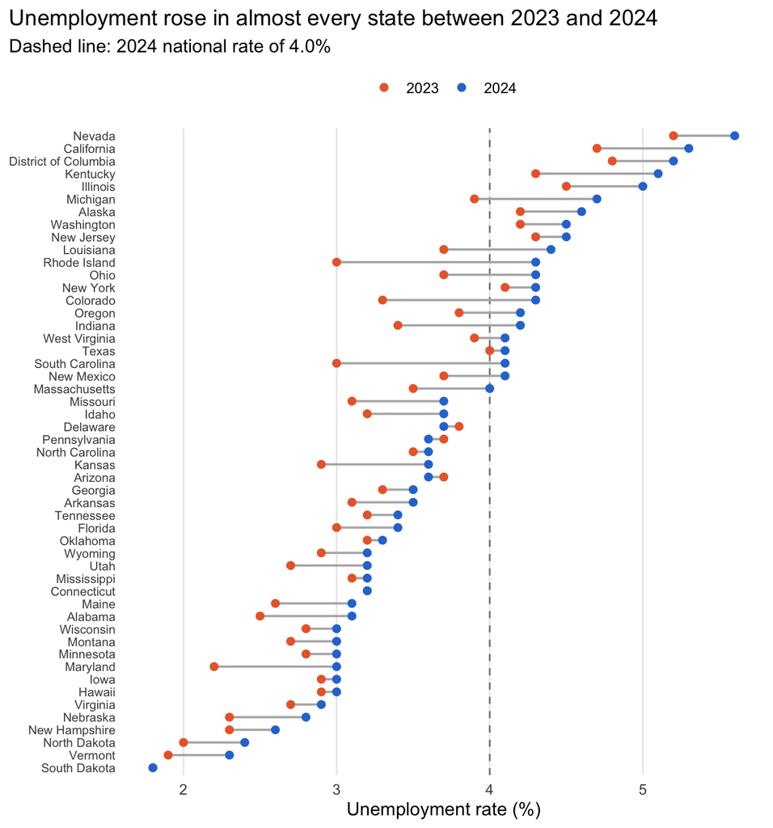

Figure 1: Unemployment rate by state, 2023 and 2024 annual averages. The dashed line is the 2024 national rate.

```r
state_rates |>
  mutate(area = fct_reorder(area, y2024)) |>
  ggplot(aes(y = area)) +
  geom_vline(xintercept = us_rate$rate[us_rate$year == 2024],
             linetype = "dashed", color = "grey55") +
  geom_segment(aes(x = y2023, xend = y2024, yend = area), color = "grey70", linewidth = 0.7) +
  geom_point(aes(x = y2023, color = "2023"), size = 2) +
  geom_point(aes(x = y2024, color = "2024"), size = 2) +
  scale_color_manual(values = c("2023" = accent_2, "2024" = accent), name = NULL) +
  labs(title = "Unemployment rose in almost every state between 2023 and 2024",
       subtitle = "Dashed line: 2024 national rate of 4.0%",
       x = "Unemployment rate (%)", y = NULL) +
  theme_p2 +
  theme(legend.position = "top", panel.grid.major.y = element_blank(),
        axis.text.y = element_text(size = 8))
```

## Largest increases and decreases

```r
bind_rows(
  state_rates |> slice_max(change, n = 5) |> mutate(group = "Largest increases"),
  state_rates |> arrange(change) |> slice_head(n = 5) |> mutate(group = "Smallest changes")
) |>
  transmute(Group = group, State = area,
            `2023 (%)` = y2023, `2024 (%)` = y2024,
            `Change (pp)` = sprintf("%+.1f", change)) |>
  kable()
```

| Group | State | 2023 (%) | 2024 (%) | Change (pp) |
| --- | --- | --- | --- | --- |
| Largest increases | Rhode Island | 3.0 | 4.3 | +1.3 |
| Largest increases | South Carolina | 3.0 | 4.1 | +1.1 |
| Largest increases | Colorado | 3.3 | 4.3 | +1.0 |
| Largest increases | Indiana | 3.4 | 4.2 | +0.8 |
| Largest increases | Michigan | 3.9 | 4.7 | +0.8 |
| Smallest changes | Pennsylvania | 3.7 | 3.6 | -0.1 |
| Smallest changes | Arizona | 3.7 | 3.6 | -0.1 |
| Smallest changes | Delaware | 3.8 | 3.7 | -0.1 |
| Smallest changes | Connecticut | 3.2 | 3.2 | +0.0 |
| Smallest changes | South Dakota | 1.8 | 1.8 | +0.0 |

```r
state_rates |>
  summarise(
    states          = n(),
    mean_2023       = round(mean(y2023), 2),
    mean_2024       = round(mean(y2024), 2),
    rose            = sum(change > 0),
    fell            = sum(change < 0),
    unchanged       = sum(change == 0)
  ) |>
  kable(col.names = c("States", "Mean 2023 (%)", "Mean 2024 (%)",
                      "Rose", "Fell", "Unchanged"))
```

| States | Mean 2023 (%) | Mean 2024 (%) | Rose | Fell | Unchanged |
| --- | --- | --- | --- | --- | --- |
| 51 | 3.32 | 3.71 | 46 | 3 | 2 |

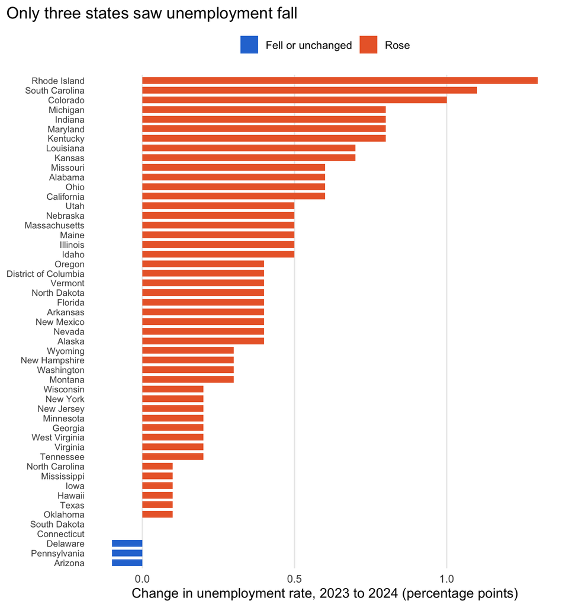

Figure 2: Change in unemployment rate from 2023 to 2024, in percentage points.

```r
state_rates |>
  mutate(area = fct_reorder(area, change),
         direction = if_else(change > 0, "Rose", "Fell or unchanged")) |>
  ggplot(aes(x = change, y = area, fill = direction)) +
  geom_col(width = 0.7) +
  scale_fill_manual(values = c("Rose" = accent_2, "Fell or unchanged" = accent), name = NULL) +
  labs(title = "Only three states saw unemployment fall",
       x = "Change in unemployment rate, 2023 to 2024 (percentage points)", y = NULL) +
  theme_p2 +
  theme(legend.position = "top", panel.grid.major.y = element_blank(),
        axis.text.y = element_text(size = 8))
```

# Conclusions

- **Unemployment rose almost everywhere.** Of the 51 states, 46 saw their rate rise between 2023 and 2024, only 3 saw it fall, and 2 were unchanged. The state average went from 3.32% to 3.71%, alongside a national move from 3.6% to 4.0%.
- **The spread between states is wide.** In 2024 the highest state rate, Nevada at 5.6%, was more than three times the lowest, South Dakota at 1.8%. California (5.3%), the District of Columbia (5.2%), Kentucky (5.1%) and Illinois (5.0%) round out the top five, while the Plains and northern New England states sit at the bottom.
- **The largest increases were not in the states with the highest rates.** Rhode Island rose the most, by +1.3 points, from 3.0% to 4.3%, followed by South Carolina (+1.1) and Colorado (+1.0). All three started below the national average and ended near or above it, so the increase reflects a genuine turn rather than an already-weak labor market getting worse.
- **The three declines were marginal.** Pennsylvania, Arizona and Delaware each fell by 0.1 points, which is within the error ranges the BLS publishes for these estimates, so they are best read as flat rather than as improvements.
- **A caution the table itself supplies.** The published error range for 2024 is roughly ±0.2 to ±0.6 points for most states. Differences smaller than that, including every one of the three declines, should not be treated as real changes.

The tidying step is what enabled this: the comparison of 2023 against 2024 requires `year` to be a variable, and in the source it existed only as a second row of column headings.